# Avaliação por Fluxos de Caixa Descontados

Ross et al. (2022), capítulo 06

Marcelo S. Perlin

EA-UFRGS

08/09/2026

## Objetivos

- Como determinar os valores presente e futuro de investimentos com vários fluxos de caixa.
- Como calcular os pagamentos e as taxas de juros de empréstimos.
- Como empréstimos são amortizados ou completamente pagos.
- Como as taxas de juros são cotadas (da maneira certa e errada).

# Valor presente de múltiplos períodos

## Fórmula VP

$$VP = \sum_{t=1}^{T} \frac{FC_t}{(1+r)^t}$$

$VP$ - Valor presente dos múltiplos fluxos de caixa

$FC_t$ - fluxo de caixa no tempo $t$

$r$ - taxa de juros

$T$ - número de períodos

## Exemplo

> Imagine que ao longo dos próximos 5 anos você irá receber dinheiro a cada ano, conforme tabela abaixo. Assumindo uma taxa de juros de 14,00%, qual o valor presente desses fluxos de caixa?

Fluxos de caixa

| Tempo | Valor |
| --- | --- |
| 0 | R$0,00 |
| 1 | R$1.000,00 |
| 2 | R$1.125,00 |
| 3 | R$1.250,00 |
| 4 | R$1.375,00 |
| 5 | R$1.500,00 |

## Solução

Fluxos de caixa

custo de capital = 14,00%

| Tempo | Valor | Valor descontado | Valor acumulado |
| --- | --- | --- | --- |
| 0 | R$0,00 | R$0,00 | R$0,00 |
| 1 | R$1.000,00 | R$877,19 | R$877,19 |
| 2 | R$1.125,00 | R$865,65 | R$1.742,84 |
| 3 | R$1.250,00 | R$843,71 | R$2.586,56 |
| 4 | R$1.375,00 | R$814,11 | R$3.400,67 |
| 5 | R$1.500,00 | R$779,05 | R$4.179,72 |

O valor presente dos fluxos de caixa é R$ 4.179,72.

## Anuidades

> Uma anuidade é um fluxo de caixa constante e igual para todo o período

Um exemplo é receber R$ 1.000,00 por ano, ao longo de 10 anos:

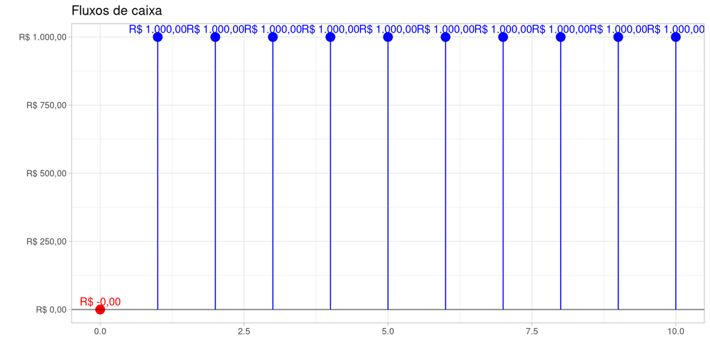

## Solução

Usando a fórmula anterior e assumindo $FC_t = FC$:

$$VP = \sum_{t=1}^{T} \frac{FC}{(1+r)^t}$$

Simplificando a fórmula:

$$VP = FC \frac{1 - \frac{1}{(1+r)^T}}{r}$$

## Exemplo anuidade

Fluxos de caixa

custo de capital = 14,00%

| Tempo | Valor | Valor descontado | Valor acumulado |
| --- | --- | --- | --- |
| 0 | R$0,00 | R$0,00 | R$0,00 |
| 1 | R$5.000,00 | R$4.385,96 | R$4.385,96 |
| 2 | R$5.000,00 | R$3.847,34 | R$8.233,30 |
| 3 | R$5.000,00 | R$3.374,86 | R$11.608,16 |
| 4 | R$5.000,00 | R$2.960,40 | R$14.568,56 |
| 5 | R$5.000,00 | R$2.596,84 | R$17.165,40 |

O valor presente dos fluxos de caixa é R$ 17.165,40.

## Perpetuidades

> Perpetuidades são fluxos de caixa constantes e perpétuos (nunca terminam)

Substituindo $T = \infty$ na fórmula do VP, temos:

$$VP = \sum_{t=1}^{\infty} \frac{FC}{(1+r)^t}$$

Simplificando e levando a equação anterior ao limite onde $T$ aproxima-se do infinito ($\infty$), temos:

$$VP=\frac{FC}{r}$$

# Valor futuro de múltiplos períodos

## Fórmula $VF$

$$VF_T = \sum_{t=1}^{T} FC_t (1+r)^{T-t}$$

$VF_T$ - Valor futuro total acumulado no tempo $T$

$FC_t$ - fluxo de caixa no tempo $t$

$r$ - taxa de juros

$T$ - número de períodos

## Ilustração

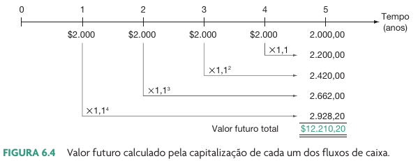

Extraído de Ross et al. (2022), página 150

## Exemplo cálculo

> Imagine que você irá depositar R$ 1.000,00 por mês na poupança pelos próximos 10 meses. Ao final do 10º mês, qual o valor encontrado na conta poupança?

Fluxos de caixa

| Tempo | Valor |
| --- | --- |
| 0 | R$0,00 |
| 1 | R$1.000,00 |
| 2 | R$1.000,00 |
| 3 | R$1.000,00 |
| 4 | R$1.000,00 |
| 5 | R$1.000,00 |
| 6 | R$1.000,00 |
| 7 | R$1.000,00 |
| 8 | R$1.000,00 |
| 9 | R$1.000,00 |
| 10 | R$1.000,00 |

## Solução

Fluxos de caixa

Taxa de juros = 0,65%

| Tempo | Valor | VF | VF acumulado |
| --- | --- | --- | --- |
| 0 | R$0,00 | R$0,00 | R$0,00 |
| 1 | R$1.000,00 | R$1.059,80 | R$1.059,80 |
| 2 | R$1.000,00 | R$1.052,98 | R$2.112,78 |
| 3 | R$1.000,00 | R$1.046,21 | R$3.158,99 |
| 4 | R$1.000,00 | R$1.039,48 | R$4.198,46 |
| 5 | R$1.000,00 | R$1.032,79 | R$5.231,26 |
| 6 | R$1.000,00 | R$1.026,15 | R$6.257,41 |
| 7 | R$1.000,00 | R$1.019,55 | R$7.276,95 |
| 8 | R$1.000,00 | R$1.012,99 | R$8.289,94 |
| 9 | R$1.000,00 | R$1.006,47 | R$9.296,42 |
| 10 | R$1.000,00 | R$1.000,00 | R$10.296,42 |

O valor futuro dos fluxos de caixa é R$ 10.296,42.

## A importância do reinvestimento dos dividendos

> Investimentos em renda variável (Ações e FIIs) dão direito ao recebimento de dividendos (parcelas do lucro)
- Esses dividendos variam de valor de acordo com o lucro e a decisão de payout
- A frequência de pagamento também varia (empresas decidem quando e como vão pagar)
- Esse dinheiro pode ser gasto ou reinvestido
- O não reinvestimento causa grande impacto no patrimônio final

## O caso da EGIE3

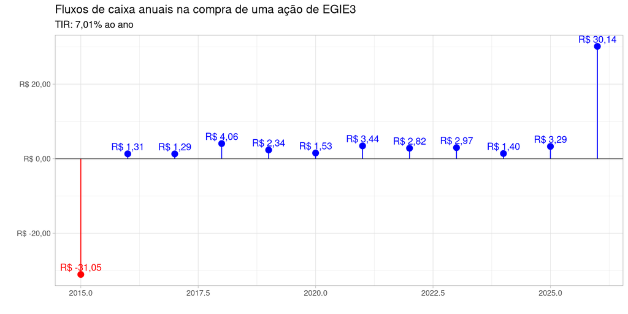

## O impacto do não reinvestimento de dividendos

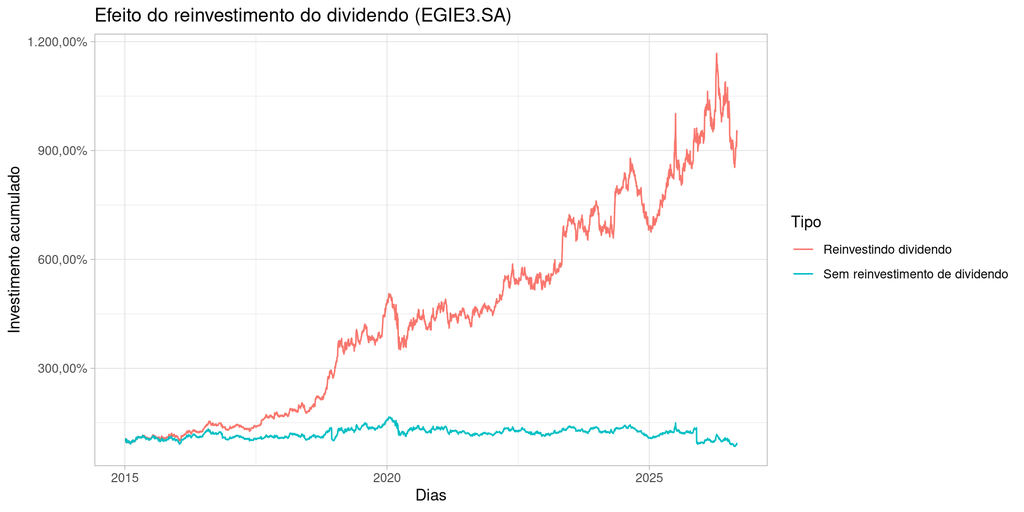

# Mudança de taxa de retorno

## Mensal para anual

Dada uma taxa SELIC hoje de 14,00% ao ano:

**Anual para mensal**

$$r_{am} = (1+r_{aa})^{1/12} - 1$$

Um retorno anual de 14,00% equivale a 1,10% ao mês.

**Mensal para anual**

$$r_{aa} = (1+r_{am})^{12} - 1$$

Um retorno mensal de 1,10% equivale a 14,00% anualmente.

# Custo de uma dívida

## CET

> O CET, **Custo Efetivo Total** é a taxa de juros **real** do empréstimo, incluindo **todas as tarifas e comissões cobradas**.
- O CET é utilizado em:
  - financiamento imobiliário
  - financiamentos em geral
  - cartão de crédito

**Cuidado!**

Apesar de ser legalmente obrigado a divulgar a taxa CET em qualquer empréstimo, o banco/vendedor geralmente esconde a CET até a assinatura do contrato!

## Exemplo CET

> Imagine pegar R$ 10.000,00 emprestado no banco a uma taxa nominal de 14,00% ao ano (SELIC), com pagamento em 3 anos.

O valor futuro (VF) a ser pago no ano 3 é de R$ 14.815,44. Porém, o banco tem os seguintes custos na operação de concessão de empréstimo:

1. taxa fixa de registro de R$ 150,00
2. custo fixo de análise de crédito de R$ 500,00

> No início da operação, o valor obtido do financiamento será de R$ 9.350,00, e não R$ 10.000,00.

## Solução CET

Os fluxos de caixa são:

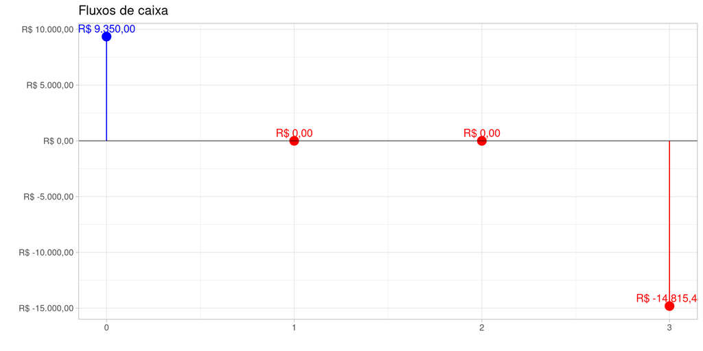

Enquanto a taxa de juros nominal era de 14,00%, a CET é equivalente a 16,58%.

## CET Real em Financiamento Imobiliário

> Em um financiamento de **R$ 200.000,00** a uma taxa nominal de **9,00% a.a.** (parcela base: R$ 1.558,97):
- **Custos adicionais mensais**:
  - Seguro MIP (Morte e Invalidez): R$ 60,00/mês
  - Seguro DFI (Danos Físicos ao Imóvel): R$ 25,00/mês
  - Taxa de Administração Bancária: R$ 25,00/mês
- **Prestação total real**: **R$ 1.668,97**/mês
- **CET Efetivo Real**: **9,83% a.a.** (em vez de 9,00% a.a.).

# Tipos de empréstimos

## Empréstimos tipo desconto

> O empréstimo tipo desconto é a forma mais simples de empréstimo. O mutuário recebe o dinheiro hoje e o paga em uma única parcela no futuro.

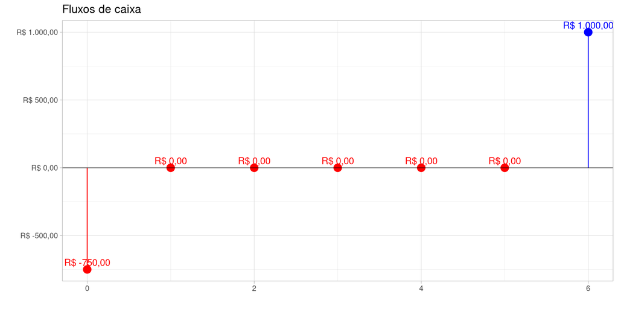

## Cálculo da CET

Calculando a TIR, temos que:

CET = 4,91%

## Empréstimos com juros constantes

> Empréstimos com juros constantes são aqueles em que o mutuário paga somente juros a cada período e paga todo o principal (o montante original do empréstimo) em algum momento futuro.

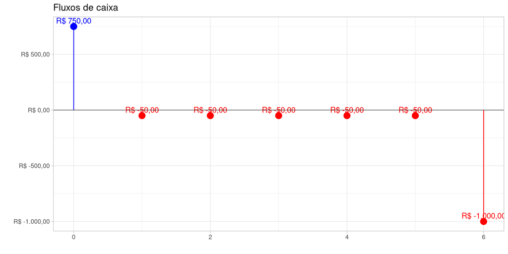

Aplicando a fórmula da TIR, temos que o CET é igual a 10,11%.

## Empréstimos com pagamento parcelado

> É aquele onde o credor exige do mutuário o pagamento de partes do montante do empréstimo ao longo do período do empréstimo.

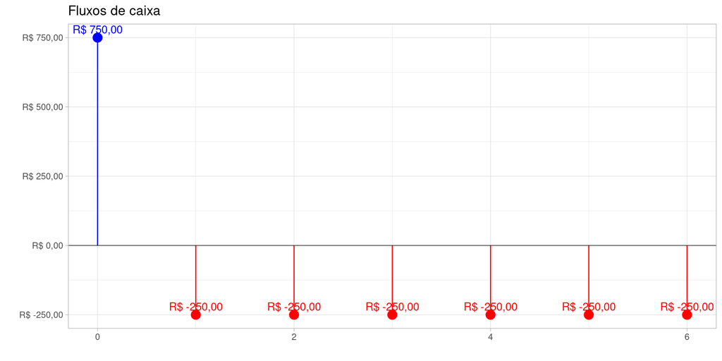

Aplicando a fórmula da TIR, temos que o CET é igual a 24,29%.

# Financiamento Imobiliário

## SAC X PRICE

- **Sistema de Amortização Constante (SAC)**
  - o tomador paga prestações decrescentes.
  - a dívida é amortizada de forma constante
- **Tabela PRICE**
  - mantém as parcelas constantes
  - geralmente vale para prazos maiores

## Exemplo Comparativo: SAC x PRICE

> Imagine um financiamento de **R$ 300.000,00**, CET de **12,00% a.a.** e prazo de **360 meses**:
- **Tabela PRICE**:
  - Parcela constante de **R$ 2.944,93** ao mês.
  - Total pago ao final: **R$ 1.060.176,11** (sendo R$ 760.176,11 de juros).
- **Sistema SAC**:
  - Amortização constante de **R$ 833,33** ao mês.
  - 1ª parcela de **R$ 3.679,97** e última parcela de **R$ 841,24**.
  - Total pago ao final: **R$ 813.818,14** (sendo R$ 513.818,14 de juros).

## Gráfico com parcelas (primeiros 24 meses)

[figure not shown]

## Amortização Extraordinária no SAC

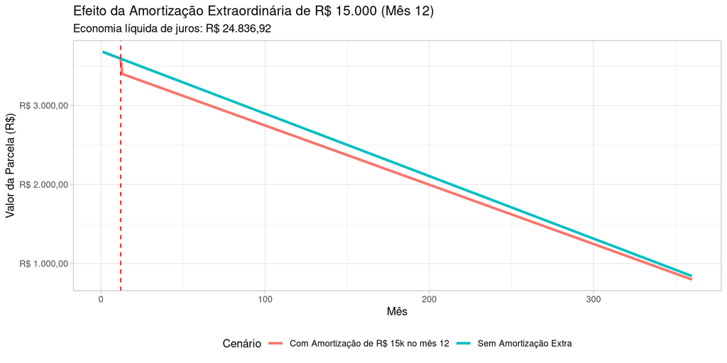

# Cuidados em um financiamento imobiliário

## Cuidados

> Financiamento imobiliário é um empréstimo aceitável para pessoa física, desde que seja feito com alguns cuidados.
- **Escolha um imóvel que caiba no seu orçamento!!**
- Nunca financie mais que 75% do imóvel, **sempre dê a maior entrada possível**
- Nunca financie mais que 30% da sua renda e use o maior prazo possível. Lembre que a sua renda hoje não é garantida para sempre (exceto alguns casos especiais)
- Dê preferência a tabela SAC, pois as parcelas são decrescentes e o valor total pago é menor
- Sempre que possível, amortize o financiamento com recursos extras
- Desde o início, tenha um plano B caso perca o emprego ou tenha uma queda de renda.

## Referências

Ross, Stephen, Randolph Westerfield, Bradford Jordan, et al. 2022. *Fundamentos de Administração Financeira*. Bookman Editora.